# STAT 420: Homework 07

Fall 2020, D. Unger

Due: Tuesday, October 27 by 11:30 PM CT

# Assignment

## Exercise 1 (Brand Rankings)

For this exercise we will use the data stored in `cookies.csv`. In order to determine which of three recipes (`A`, `B`, and `C`) to use, a cookie manufacturer divided 18 individuals at random into three groups and asked each one of them to rate one recipe on a scale from 0 to 100.

Consider the model $y_{ij} = \mu + \alpha_i + e_{ij}$ where $\sum \alpha_i = 0$ and $e_{ij} \sim N(0,\sigma^{2})$. Here, $\mu + \alpha_i$ represents the mean of group (recipe) $i$.

Create side-by-side boxplots of the ratings of the three recipes. Test for a difference among the three recipes. If there is a difference, which recipes are different? Use $\alpha = 0.10$ for all tests. Which recipe would you use?

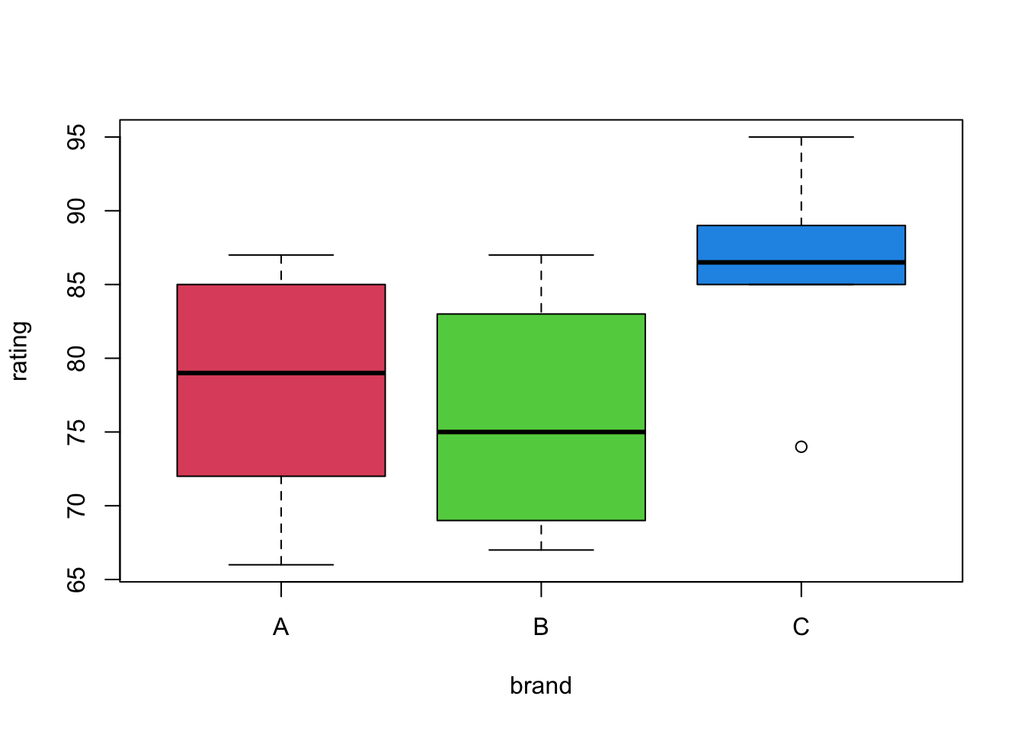

```r
cookies = read.csv("cookies.csv")
boxplot(rating~brand,data=cookies,col=2:5)
```

```r
cookies_aov = aov(rating~brand,data=cookies)
summary(cookies_aov)
```

```
##             Df Sum Sq Mean Sq F value Pr(>F)
## brand        2    336     168   2.897 0.0864 .
## Residuals   15    870      58
## ---
## Signif. codes:  0 '***' 0.001 '**' 0.01 '*' 0.05 '.' 0.1 ' ' 1
```

The p-value is less than the alpha, so we can reject the null hypothesis at the 0.10 significance level, and can say that recipe has an effect on rating.

```r
TukeyHSD(cookies_aov,conf.level=0.10)
```

```
##   Tukey multiple comparisons of means
##     10% family-wise confidence level
##
## Fit: aov(formula = rating ~ brand, data = cookies)
##
## $brand
##     diff       lwr         upr     p adj
## B-A   -2 -3.929355 -0.07064459 0.8930126
## C-A    8  6.070645  9.92935541 0.1969983
## C-B   10  8.070645 11.92935541 0.0907760
```

We see that the difference between B and C is significant, and since C has the higher mean I would choose C.

## Exercise 2 (Concrete Strength)

An engineer is investigating the strength of concrete beams made from four types of cement and employing three curing processes. For each cement-curing combination, three beams are made and their breaking strength is measured. (A $4 \times 3$ randomized factorial design with $3$ replicates.)

Consider the model:

$$y_{ijk} = \mu + \alpha_i + \beta_j + (\alpha \beta)_{ij} + \epsilon_{ijk}$$

where

$$i = 1, \cdots I \quad j = 1, \cdots J \quad k = 1 \cdots, K$$

and $\epsilon_{ijk}$ are $N(0, \sigma^2)$ random variables.

With constraints:

$$\sum \alpha_i = 0 \quad \quad \sum \beta_j = 0.$$

Additionally:

$$(\alpha \beta)_{1j} + (\alpha \beta)_{2j} + (\alpha \beta)_{3j} = 0 \\
(\alpha \beta)_{i1} + (\alpha \beta)_{i2} + (\alpha \beta)_{i3} + (\alpha \beta)_{i4} = 0$$

for any $i$ or $j$.

Let $\alpha_i$ represent the main effect for cement, which has four levels.

Let $\beta_j$ represent the main effect for curing process, which takes three levels.

The data can be found in `concrete.csv`. Test for interaction between the two factors. If necessary, test for main effects. Use $\alpha = 0.05$ for all tests. State the final model you choose. Also, create an interaction plot. Does this plot make sense for the model you chose? With the model you chose (and then fit), create a table that shows the estimated mean for each of the $4 \times 3$ factor level combinations.

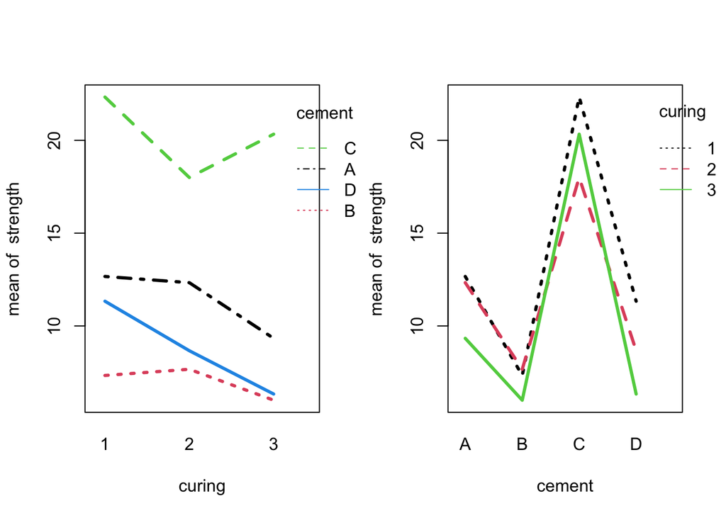

```r
concrete = read.csv("concrete.csv")
par(mfrow=c(1,2))
with(concrete,interaction.plot(curing,cement,strength,lwd=3,col=1:4))
with(concrete,interaction.plot(cement,curing,strength,lwd=3,col=1:3))
```

Interaction would mean that lines would cross while heading in different directions. Although we do not see that here, we do see some overlap on the right panel. To investigate more, we can fit each possible model.

```r
summary(aov(strength~curing*cement,data=concrete))
```

```
##               Df Sum Sq Mean Sq F value   Pr(>F)
## curing         1   51.0   51.04  10.626  0.00293 **
## cement         3  929.0  309.66  64.464 1.09e-12 ***
## curing:cement  3   11.8    3.93   0.818  0.49472
## Residuals     28  134.5    4.80
## ---
## Signif. codes:  0 '***' 0.001 '**' 0.01 '*' 0.05 '.' 0.1 ' ' 1
```

```r
summary(aov(strength~curing+cement,data=concrete))
```

```
##             Df Sum Sq Mean Sq F value   Pr(>F)
## curing       1   51.0   51.04   10.82  0.00251 **
## cement       3  929.0  309.66   65.62 1.59e-13 ***
## Residuals   31  146.3    4.72
## ---
## Signif. codes:  0 '***' 0.001 '**' 0.01 '*' 0.05 '.' 0.1 ' ' 1
```

```r
concrete_int = aov(strength~curing*cement,data=concrete)
concrete_add = aov(strength~curing+cement,data=concrete)
concrete_table = expand.grid(curing=unique(concrete$curing), cement=unique(concrete$cement))
get_est_means = function(model,table) {
  mat = matrix(predict(model,table),nrow=4,ncol=3,byrow=TRUE)
  colnames(mat)=c("1","2","3")
  rownames(mat) = c("A","B","C","D")
  mat
}
additive_means = get_est_means(model=concrete_add,table=concrete_table)
additive_means["A",] - additive_means["B",]
```

```
##        1        2        3
## 4.444444 4.444444 4.444444
```

The following are the estimated means for each of the 4x3 factor level combinations.

```r
knitr::kable(get_est_means(model=concrete_add,table=concrete_table))
```

[output not shown]

A total of $60$ rats were used in an experiment about the effects of protein quantity and source on weight gain. The experiment used a $2 \times 3$ randomized factorial design with $10$ replicates. (For each of the $6$ treatments, $10$ rats were randomly chosen.)

Each rat was fed a `low` or `high` protein diet from one of three sources: `beef`, `cereal`, or `pork`. After a period of time, the weight `gain` (the response, $y$) of each was measured in grams.

Consider the model:

$$y_{ijk} = \mu + \alpha_i + \beta_j + (\alpha \beta)_{ij} + \epsilon_{ijk}$$

where

$$i = 1, \cdots I \quad j = 1, \cdots J \quad k = 1 \cdots, K$$

and $\epsilon_{ijk}$ are $N(0, \sigma^2)$ random variables.

With constraints:

$$\sum \alpha_i = 0 \quad \quad \sum \beta_j = 0.$$

Additionally:

$$(\alpha \beta)_{1j} + (\alpha \beta)_{2j} + (\alpha \beta)_{3j} = 0 \\
(\alpha \beta)_{i1} + (\alpha \beta)_{i2} + (\alpha \beta)_{i3} + (\alpha \beta)_{i4} = 0$$

for any $i$ or $j$.

Let $\alpha_i$ represent the main effect for protein quantity, which has two levels; `high` and `low`.

Let $\beta_j$ represent the main effect for protein source, which takes three levels; `beef`, `cereal` and `pork`.

The data can be found in `rat_wt.csv`. Test for interaction between the two factors. If necessary, test for main effects. Use $\alpha = 0.10$ for all tests. State the final model you choose. Also, create an interaction plot. Does this plot make sense for the model you chose? With the model you chose (and then fit), create a table that shows the estimated mean for each of the $2 \times 3$ factor level combinations.

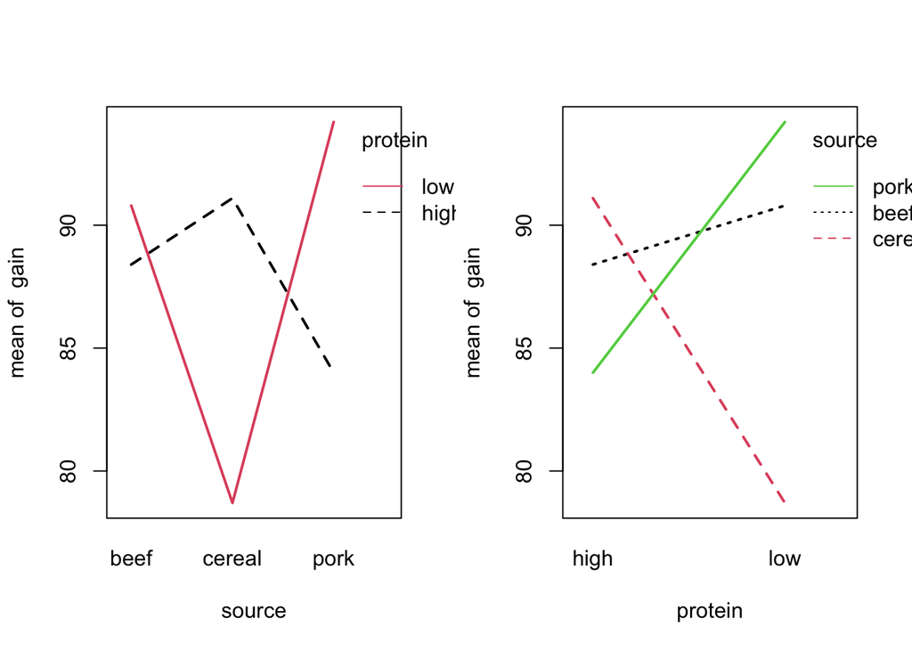

```r
rats = read.csv("rat_wt.csv")
par(mfrow=c(1,2))
with(rats, interaction.plot(source, protein, gain, lwd = 2, col = 1:4))
with(rats, interaction.plot(protein, source, gain, lwd = 2, col = 1:3))
```

There is some itneraction as we see lines crossing while heading in different directions in both panels.

```r
summary(aov(gain~source*protein,data=rats))
```

```
##                Df Sum Sq Mean Sq F value Pr(>F)
## source          2    267   133.3   0.492 0.6139
## protein         1      0     0.1   0.000 0.9875
## source:protein  2   1318   658.9   2.434 0.0972 .
## Residuals      54  14615   270.6
## ---
## Signif. codes:  0 '***' 0.001 '**' 0.01 '*' 0.05 '.' 0.1 ' ' 1
```

Because the p-value is less than the alpha, we find that the interaction is significant.

```r
rats_int = aov(gain~source*protein,data=rats)
get_est_means = function(model,table) {
  mat = matrix(predict(model, table), nrow = 2, ncol = 3, byrow = TRUE)
  colnames(mat) = c("pork", "cereal", "beef")
  rownames(mat) = c("high", "low")
  mat
}

rats_table = expand.grid(source=unique(rats$source),protein=unique(rats$protein))
knitr::kable(get_est_means(model=rats_int,table=rats_table))
```

[output not shown]

## Exercise 4 (Sample Size, Power)

Now that we’re performing experiments, getting more data means finding more test subjects, running more lab tests, etc. In other words, it will cost more time and money.

We’d like to design our experiment so that we have a good chance of detecting an interesting effect size, without spending too much money. There’s no point in running an experiment if there’s only a very low chance that it has a significant result **that you care about**. (Not all statistically significant results have practical value.)

Suppose we will run an experiment that compares three treatments: `A`, `B`, and `C`. From previous study, we believe the shared variance could be $\sigma^2 = 1$.

Consider the model $y_{ij} = \mu_j + e_{ij}$ where $e_{ij} \sim N(0,\sigma^{2})$. Here $j = 1, 2, 3$, for `A`, `B`, and `C`.

The null hypothesis of the test we will run is:

$$H_0: \mu_A = \mu_B = \mu_C$$

Suppose that we’re interested in an alternative where

$$\mu_A = -1, \mu_B = 0, \mu_C = 1$$

Mostly, we’ve used simulation to verify results. Now, we’ll use simulation to save money (in place of some rather difficult mathematics)!

Use simulation to determine the *minimum* sample size that has *at least* a 90% chance to reject the null hypothesis when that alternative is true and $\alpha = 0.05$. That is, find the sample size which gives a **power** of at least 0.90 for the stated alternative. Consider only balanced designs, which have the same number of replications in each group. For each sample size, use at least 250 simulations. (More simulations will give a better estimate of the power and will create a smoother resulting curve.)

Plot your results. What sample size do you choose?

Before performing the simulations, set a seed value equal to **your** birthday, as was done in the previous homework assignments.

```r
birthday = 19990503
set.seed(birthday)
```

```r
library(broom)
sim_anova = function(n = 10, mu_a = 0, mu_b = 0, mu_c = 0, mu_d = 0, sigma = 1, stat = TRUE) {

  # create data from one-way ANOVA model with four groups of equal size
  # response simulated from normal with group mean, shared variance
  # group variable indicates group A, B, C or D
  sim_data = data.frame(
    response = c(rnorm(n = n, mean = mu_a, sd = sigma),
                 rnorm(n = n, mean = mu_b, sd = sigma),
                 rnorm(n = n, mean = mu_c, sd = sigma)),
    group = c(rep("A", times = n), rep("B", times = n),
              rep("C", times = n))
  )

  # obtain F-statistic and p-value for testing difference of means
  # use lm instead of aov for better result formatting with glance
  aov_results = lm(response ~ group, data = sim_data)
  f_stat = glance(aov_results)$statistic
  p_val  = glance(aov_results)$p.value

  # return f_stat if stat = TRUE, otherwise, p-value
  ifelse(stat, f_stat, p_val)

}
```

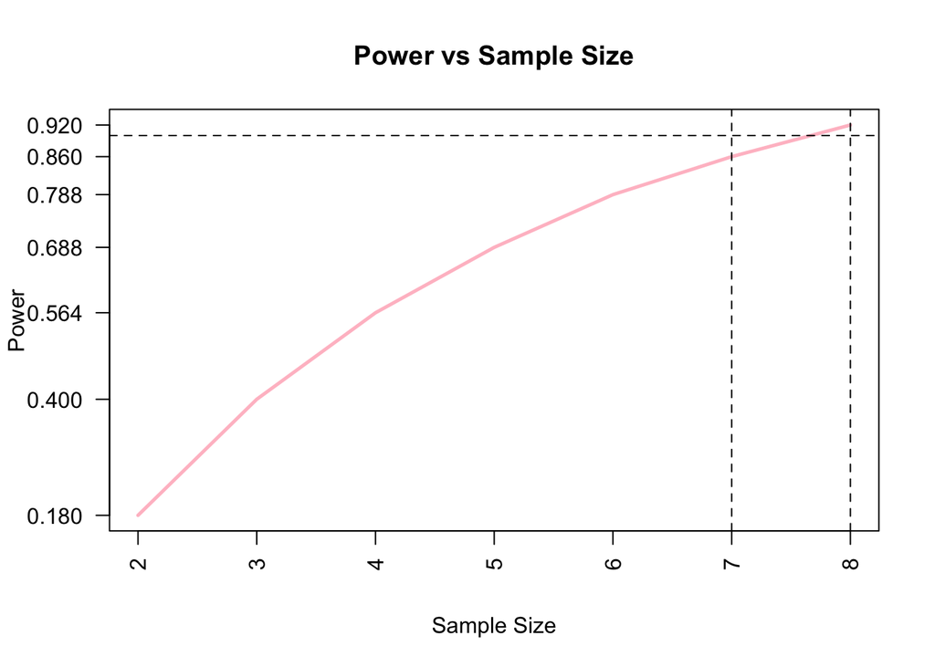

```r
y = c(0)
x = c(0)
for (i in 2:100){
  p_vals = replicate(n = 500, sim_anova(n=i,mu_a = -1, mu_b = 0, mu_c = 1,sigma = 1, stat = FALSE))
  y = c(y,mean(p_vals < 0.05))
  if(is.na(y[i])){
    y[i] = 0
  }
  x=c(x,i)
  if(y[i]>0.9){
    break;
  }

}

plot(x[2:length(x)],y[2:length(x)],type="n", main="Power vs Sample Size", xlab = "Sample Size", ylab = "Power",xaxt="n",yaxt="n")
axis(1, at = x[2:length(x)], las=2)
axis(2, at = y[2:length(x)], las=2)
lines(x[2:length(x)],y[2:length(x)],col="pink",lwd=2.5)
abline(h=0.9,lty=2)
abline(v=i-1,lty=2)
abline(v=i,lty=2)
```

For a sample size of 8, we get about 90% confidence.

## Exercise 5 (Balanced Design, Power)

Why do we use a balanced (equal number of replicates in each group) design? To maximize power. Let’s verify this with simulation.

Consider a simple example with $2$ groups A and B and a *total* sample size of $N = 10$. Where should we place these samples (replicates) between A and B? Obviously, at least one replicate needs to be in each, but after that, we can choose.

Consider the model $y_{ij} = \mu_j + e_{ij}$ where $e_{ij} \sim N(0,\sigma^{2} = 1)$. Here $j = 1, 2$, for `A` and `B`.

The null hypothesis of the test we will run is:

$$H_0: \mu_A = \mu_B$$

Suppose that we’re interested in an alternative where

$$\mu_A = 0, \mu_B = 2$$

Calculate the power for each of the possible placements of the replicates with $\alpha = 0.05$. (Essentially, for $n_a = 1, 2, \ldots 9$.) For each possibility, use at least 500 simulations. Plot the results. Does balance provide the best power?

Before performing the simulations, set a seed value equal to **your** birthday, as was done in the previous homework assignments.

```r
birthday = 19990503
set.seed(birthday)
```

```r
sim_anova = function(n = 10, mu_a = 0, mu_b = 0, n_a = 5, n_b = 5, sigma = 1, stat = TRUE) {

  sim_data = data.frame(
    response = c(rnorm(n = n, mean = mu_a, sd = sigma),
                 rnorm(n = n, mean = mu_b, sd = sigma)),
    group = c(rep("A", times = n), rep("B", times = n))
  )


  aov_results = lm(response ~ group, data = sim_data)
  f_stat = glance(aov_results)$statistic
  p_val  = glance(aov_results)$p.value


  ifelse(stat, f_stat, p_val)

}
```

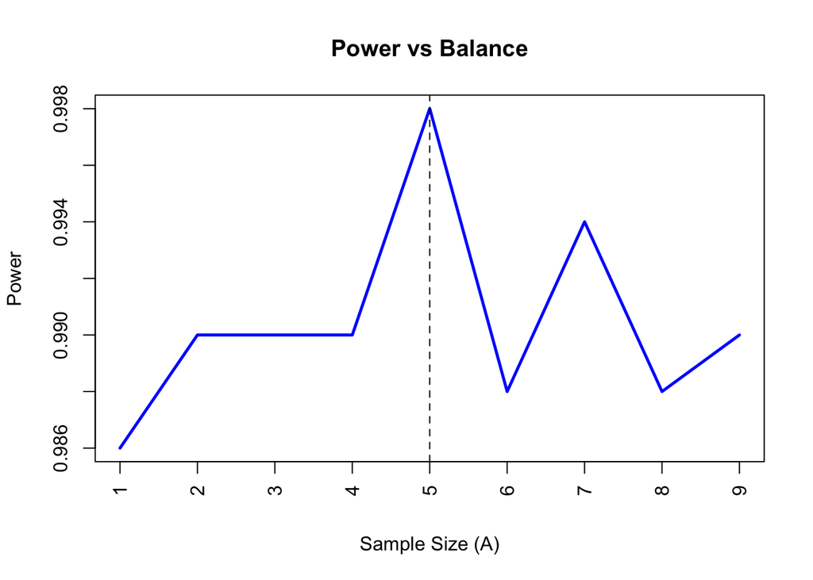

```r
par(mfrow=c(1,1))
mean_p_vals = rep(0,9)


x = 1:9
for (a in x){
  b = 10-a;
  p_vals = replicate(n = 500, sim_anova(mu_a = 0, mu_b = 2, n_a = a, n_b = b,sigma = 1, stat = FALSE))

  mean_p_vals[a]=mean(p_vals < 0.05)
}

plot(x,mean_p_vals,type="n", main="Power vs Balance", xlab = "Sample Size (A)", ylab = "Power",xaxt="n")
axis(1, at = x, las=2)
lines(x,mean_p_vals,col="blue",lwd=2.5)
abline(v =5 ,lty = 2)
```